# By way of introduction…

- 3 main facilities for producing graphics in R: **base**, **`lattice`**, and **`ggplot2`**
- In practice, these facilities are grouped into two camps: “basic” and “advanced”
- A better formulation: quick/dirty v. involved/fancy

# The data

- All Summer Olympic medalists from 1896-2008
- Variables include name, gender, country, country code (`NOC`), sporting event, and type of medal won
- We don't actually care about names of winners: we're interested in how many medals that different countries won

For more info, see [The Guardian Datablog Olympic medal winners: every one since 1896 as open data](https://www.theguardian.com/sport/datablog/2012/jun/25/olympic-medal-winner-list-data)

First, we'll use `dplyr` and `tidyr` to count the medals of each type won, for each country and each year.

```r
head(medals)
```

```
##     City    Sport Discipline               Athlete NOC Gender
## 1 Athens Aquatics   Swimming         HAJOS, Alfred HUN    Men
## 2 Athens Aquatics   Swimming      HERSCHMANN, Otto AUT    Men
## 3 Athens Aquatics   Swimming     DRIVAS, Dimitrios GRE    Men
## 4 Athens Aquatics   Swimming    MALOKINIS, Ioannis GRE    Men
## 5 Athens Aquatics   Swimming    CHASAPIS, Spiridon GRE    Men
## 6 Athens Aquatics   Swimming CHOROPHAS, Efstathios GRE    Men
##                        Event Event_gender  Medal Year Country
## 1             100m freestyle            M   Gold 1896 Hungary
## 2             100m freestyle            M Silver 1896 Austria
## 3 100m freestyle for sailors            M Bronze 1896  Greece
## 4 100m freestyle for sailors            M   Gold 1896  Greece
## 5 100m freestyle for sailors            M Silver 1896  Greece
## 6            1200m freestyle            M Bronze 1896  Greece
```

```r
# dplyr and tidyr refresher
medal_counts <- medals %>%
  group_by(Medal, Year, NOC) %>%
  summarise(count = n())
head(medal_counts)
```

```
## # A tibble: 6 x 4
## # Groups:   Medal, Year [1]
##   Medal   Year NOC   count
##   <chr>  <int> <chr> <int>
## 1 Bronze  1896 AUT       2
## 2 Bronze  1896 DEN       3
## 3 Bronze  1896 FRA       2
## 4 Bronze  1896 GBR       2
## 5 Bronze  1896 GER       2
## 6 Bronze  1896 GRE      22
```

This table is in tidy format. Wide (untidy) format can be useful for plotting in base plot (more on this later)

```r
medal_counts_wide <- medal_counts %>% spread(key = Medal, value = count) %>%
  ungroup() %>%
  mutate(Bronze = ifelse(is.na(Bronze), 0, Bronze)) %>%
  mutate(Silver = ifelse(is.na(Silver), 0, Silver)) %>%
  mutate(Gold = ifelse(is.na(Gold), 0, Gold))
head(medal_counts_wide)
```

```
## # A tibble: 6 x 5
##    Year NOC   Bronze  Gold Silver
##   <int> <chr>  <dbl> <dbl>  <dbl>
## 1  1896 AUS        0     2      0
## 2  1896 AUT        2     2      1
## 3  1896 DEN        3     1      2
## 4  1896 FRA        2     5      4
## 5  1896 GBR        2     2      3
## 6  1896 GER        2    26      5
```

Finally, let's subset the data to gold medal counts for the US, for easier plotting.

```r
usa_gold_medals <-  medal_counts %>%
  dplyr::filter(Medal == "Gold") %>%
  dplyr::filter(NOC == "USA")
```

# Base graphics

The general call for base plot looks something like this:

```r
plot(x = , y = , ...)
```

Additional parameters can be passed in to customize the plot:

- type: scatterplot? lines? etc
- main: a title
- xlab, ylab: x-axis and y-axis labels
- col: color, either a string with the color name or a vector of color names for each point

More layers can be added to the plot with additional calls to `lines`, `points`, `text`, etc.

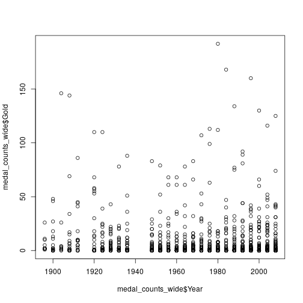

```r
plot(medal_counts_wide$Year, medal_counts_wide$Gold) # Basic
```

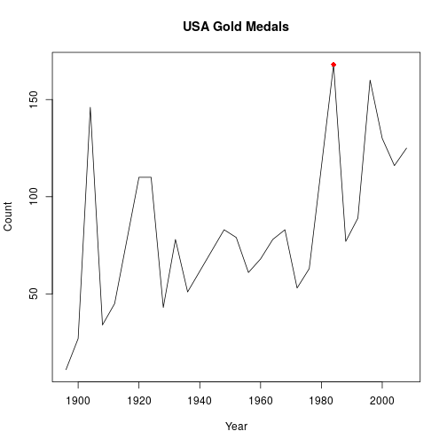

```r
plot(usa_gold_medals$Year, usa_gold_medals$count, type = "l",
     main = "USA Gold Medals",
     xlab = "Year", ylab = "Count") # with updated parameters
points(x = 1984, y = usa_gold_medals$count[usa_gold_medals$Year == 1984],
       col = "red", pch = 16)
```

## Other plot types

These are just a few other types of plots you can make in base graphics.

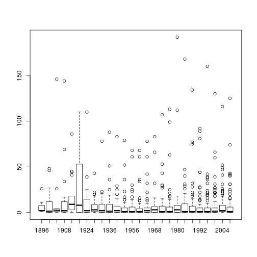

```r
boxplot(Gold~Year, data = medal_counts_wide)
```

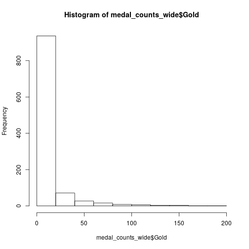

```r
hist(medal_counts_wide$Gold)
```

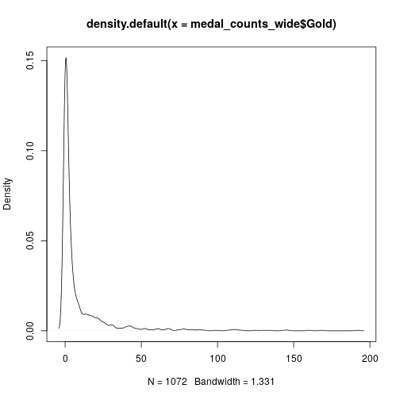

```r
plot(density(medal_counts_wide$Gold))
```

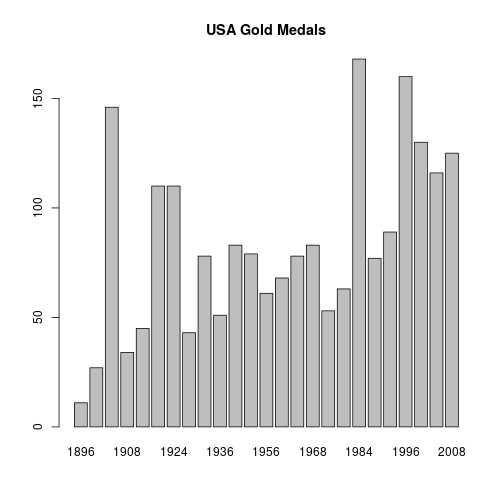

```r
barplot(usa_gold_medals$count, width = 4, names.arg = usa_gold_medals$Year,
                               main = "USA Gold Medals")
```

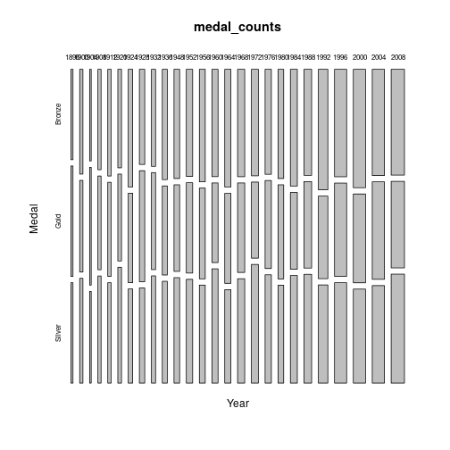

```r
mosaicplot(Year~Medal, medal_counts)
```

## Object-oriented plots

- Base graphics often recognizes the object type and will implement specific plot methods
- lattice and ggplot2 generally **don't** exhibit this sort of behavior

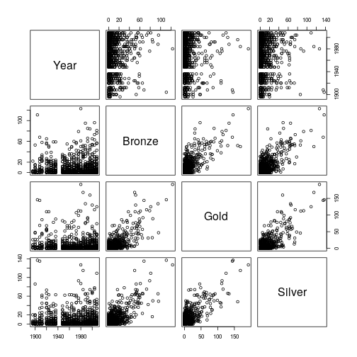

```r
medal_lm <- lm(Gold ~ Bronze + Silver, data = medal_counts_wide)

# Calls plotting method for class of the dataset ("data.frame")
plot(medal_counts_wide %>% select(-NOC))
```

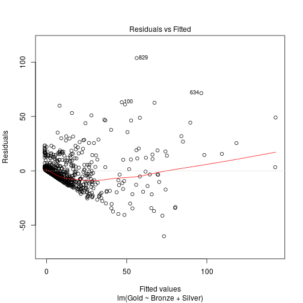

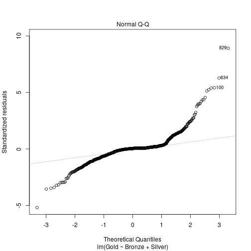

```r
# Calls plotting method for class of medal_lm object ("lm"), print first two plots only
plot(medal_lm, which=1:2)
```

## Pros/cons of base graphics

- Good for exploratory data analysis and sanity checks
- Syntax is inconsistent across functions: some take x,y while others take formulas
- Defaults plotting parameters are ugly and it can be difficult to customize

# `lattice` and `ggplot2`

`lattice` is

a) faster (though only noticeable over many and large plots)

b) simpler (at first)

c) better at trellis graphs

d) able to do 3d graphs

`ggplot2` is

a) generally more elegant

b) more syntactically logical (and therefore simpler, once you learn it)

c) better at grouping

d) able to interface with maps

# Basic usage: `lattice`

The general call for `lattice` graphics looks something like this:

```r
# NOT run
graph_type(formula, data = , [options])
```

The most common graph types:

- `xyplot`: generic scatterplot
- `barchart`: bar plots
- `bwplot`: box-and-whisker plots
- `histogram`: histograms or kernel density plots
- `cloud`: 3D scatterplot

The specifics of the **formula** differ for each graph type, but the general format is straightforward

```r
~y            # Show the distribution of y

y~x           # Show the relationship between x and y

y~x|A         # Show the relationship between x and y conditional on the values of A

y~x|A*B       # Show the relationship between x and y conditional on the combinations of A and B

z~y*x         # Show the 3D relationship between x, y, and z
```

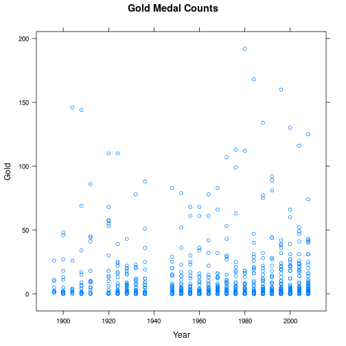

```r
xyplot(Gold~Year, data = medal_counts_wide, main = "Gold Medal Counts")
```

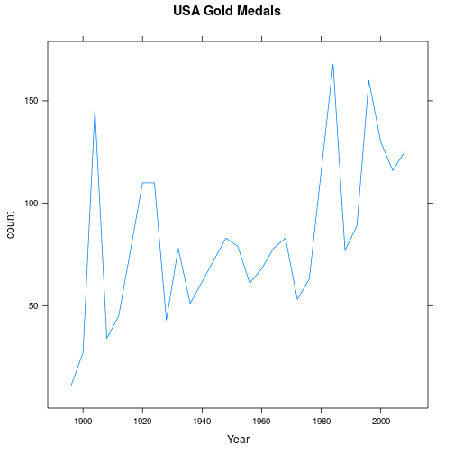

```r
xyplot(count~Year, data = usa_gold_medals, type = "l", main = "USA Gold Medals")
```

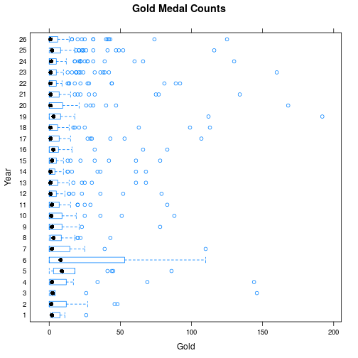

```r
# Boxplot
bwplot(Year~Gold, data = medal_counts_wide, main = "Gold Medal Counts")
```

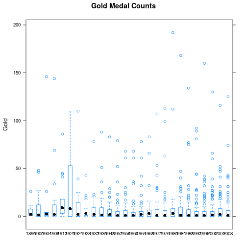

```r
# Flip the coordinates so year increases on the x-axis
# Explicitly turn Year into a factor
bwplot(Gold~factor(Year), data = medal_counts_wide, main = "Gold Medal Counts",
                  horizontal = FALSE)
```

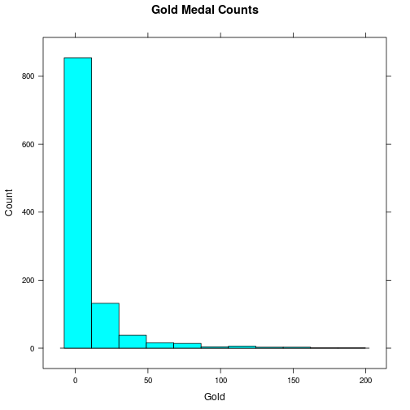

```r
# Histogram
histogram(~Gold, medal_counts_wide, type="count", main = "Gold Medal Counts")
```

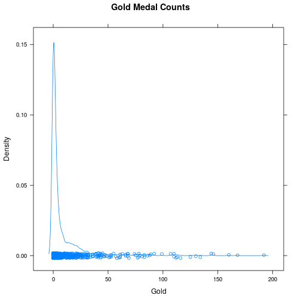

```r
# Density plot
densityplot(~Gold, medal_counts_wide, main = "Gold Medal Counts")
```

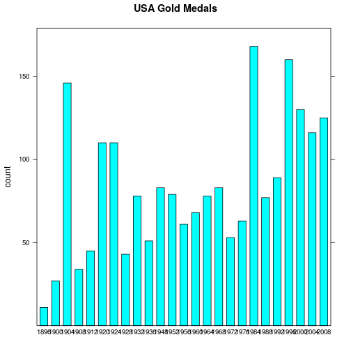

```r
# Bar chart
barchart(count~factor(Year), data = usa_gold_medals, width = 4,
                     main = "USA Gold Medals", horizontal = FALSE)
```

## Pros/cons of `lattice`

- `lattice` is useful for comparing cross-sectional variation in **trellis plots**
- Plots are generated in a single function call: you can't go back and add more once it's created
- Becoming a proficient user of lattice requires learning a huge array of graph-specific formulas and options

# Basic usage: `ggplot2`

The general call for `ggplot2` graphics looks something like this:

```r
# NOT run
ggplot(data = , aes(x = ,y = , [options])) + geom_xxxx() + ... + ... + ...
```

Note that `ggplot2` graphs in layers in a *continuing call* (hence the endless +…+…+…), which really makes the extra layer part of the call

```r
... + geom_xxxx(data = , aes(x = , y = ,[options]), [options]) + ... + ... + ...
```

You can see the layering effect by comparing the same graph with different colors for each layer

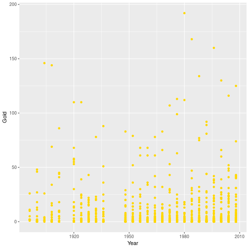

```r
p <- ggplot(data = medal_counts_wide, aes(x = Year, y = Gold)) +
                 geom_point(color = "gold")
p
```

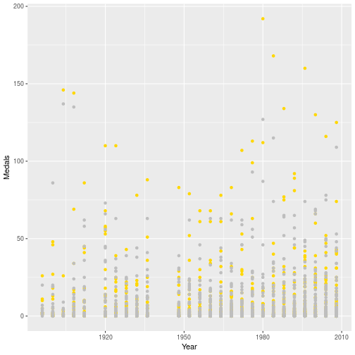

```r
p + geom_point(aes(x = Year, y = Silver), color = "gray") + ylab("Medals")
```

## Grammar of Graphics

`ggplot2` syntax is very different from base graphics and lattice. It's built on the **grammar of graphics**. The basic idea is that the visualization of all data requires four items:

1) One or more **statistics** conveying information about the data (identities, means, medians, etc.)

2) A **coordinate system** that differentiates between the intersections of statistics (at most two for `ggplot`, three for `lattice`)

3) **Geometries** that differentiate between off-coordinate variation in *kind*

4) **Scales** that differentiate between off-coordinate variation in *degree*

`ggplot2` allows the user to manipulate all four of these items.

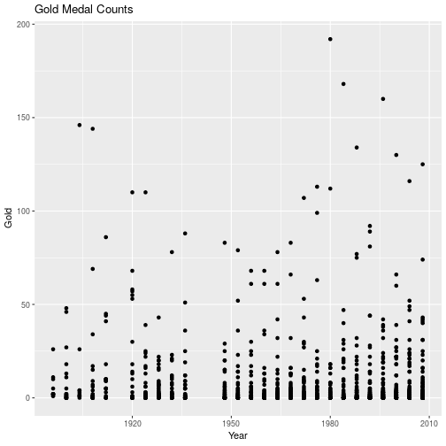

```r
ggplot(medal_counts_wide, aes(x = Year, y = Gold)) + geom_point() +
                          ggtitle("Gold Medal Counts")
```

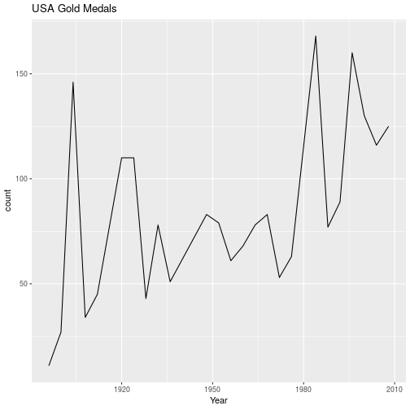

```r
ggplot(usa_gold_medals, aes(x = Year, y = count)) + geom_line() +
                        ggtitle("USA Gold Medals")
```

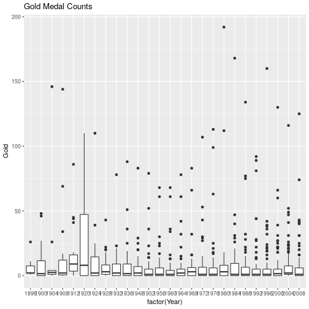

```r
# Boxplots
ggplot(medal_counts_wide, aes(x = factor(Year), y = Gold)) +
                          geom_boxplot() + ggtitle("Gold Medal Counts")
```

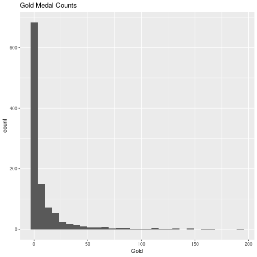

```r
# Histogram
ggplot(medal_counts_wide, aes(x = Gold)) + geom_histogram() +
                          ggtitle("Gold Medal Counts")
```

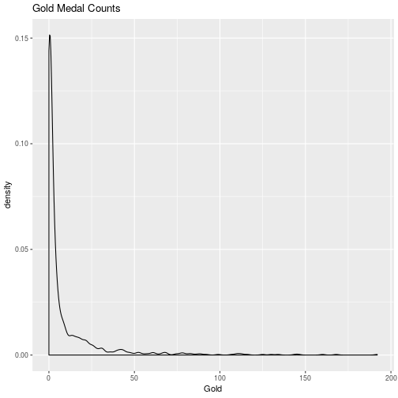

```r
# Density plot
ggplot(medal_counts_wide, aes(x = Gold)) + geom_density() +
                          ggtitle("Gold Medal Counts")
```

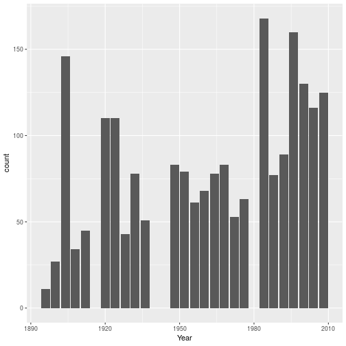

```r
# Bar chart
ggplot(usa_gold_medals, aes(x = Year, y = count)) + geom_bar(stat = "identity")
```

## `ggplot2` and tidy data

- `ggplot2` plays nice with `dplyr` and pipes. If you want to manipulate your data specifically for one plot but not save the new dataset, you can call your `dplyr` chain and pipe it directly into a `ggplot` call.

```r
# This combines the subsetting and plotting into one step
medal_counts %>%
  dplyr::filter(Medal == "Gold") %>%
  dplyr::filter(NOC == "USA") %>%
  ggplot(aes(x = Year, y = count)) + geom_line()
```

- Base graphics/lattice and `ggplot2` have one big difference: `ggplot2` **requires** your data to be in tidy format. For base graphics, it can actually be helpful *not* to have your data in tidy format. The difference is that `ggplot` treats `Medal` as an aesthetic parameter that differentiates kinds of statistics, whereas base graphics treats each (year, medal) pair as a set of inputs to the plot. Compare:

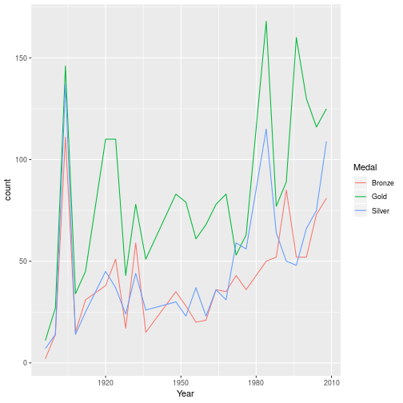

```r
usa_all_medals <- medal_counts %>%
  dplyr::filter(NOC == "USA")

# ggplot2 call
ggplot(data = usa_all_medals, aes(x = Year, y = count)) +
            geom_line(aes(color = Medal))
```

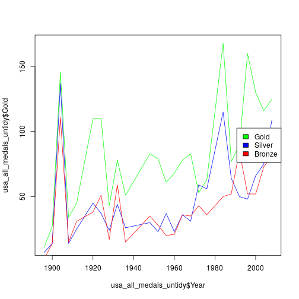

```r
usa_all_medals_untidy <- medal_counts_wide %>%
  dplyr::filter(NOC == "USA")

# Base graphics call
plot(usa_all_medals_untidy$Year, usa_all_medals_untidy$Gold, col = "green",
                                 type = "l")
lines(usa_all_medals_untidy$Year, usa_all_medals_untidy$Silver, col = "blue")
lines(usa_all_medals_untidy$Year, usa_all_medals_untidy$Bronze, col = "red")
legend("right", legend = c("Gold", "Silver", "Bronze"),
                fill = c("green", "blue", "red"))
```

## Pros/cons of `ggplot2`

- Allows you to add features in “layers”
- Automatically adjusts spacing and sizing as you add more layers
- Requires data to be in tidy format
- Syntax is different from base R – there is a learning curve
- Plots are actually objects. You can assign them to a variable and do things with it (more on this later)

# Comparing `lattice` and `ggplot2`

- Density Plots
- Scatter Plots
- Line Plots
- Bar plots
- Box plots
- Trellis Plots
- Contour Plots
- Tile/Image Plots
- 3D Plots (`lattice`)

# `lattice` v. `ggplot2`: Densities

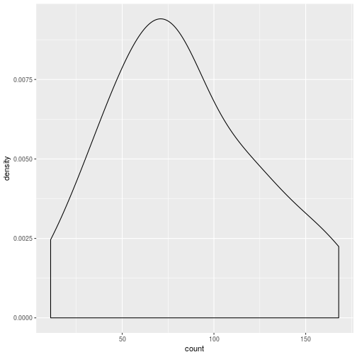

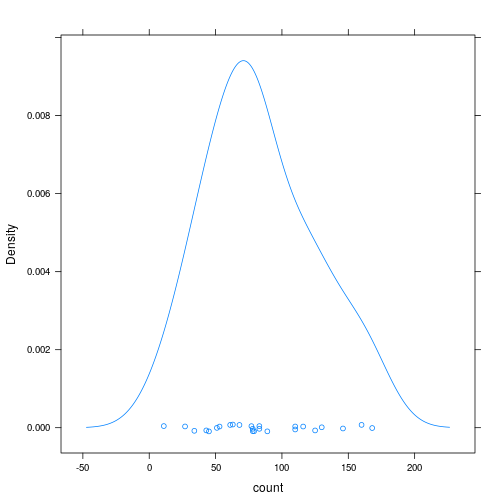

```r
ggplot(data = usa_gold_medals, aes(x = count)) + geom_density() # ggplot2
densityplot(~count, data = usa_gold_medals) # lattice
```